# Practical Machine Learning Course Project

## Introduction

Using devices such as Jawbone Up, Nike FuelBand, and Fitbit it is now possible to collect a large amount of data about personal activity relatively inexpensively. These type of devices are part of the quantified self movement – a group of enthusiasts who take measurements about themselves regularly to improve their health, to find patterns in their behavior, or because they are tech geeks. One thing that people regularly do is quantify how much of a particular activity they do, but they rarely quantify how well they do it. In this project, your goal will be to use data from accelerometers on the belt, forearm, arm, and dumbell of 6 participants. They were asked to perform barbell lifts correctly and incorrectly in 5 different ways. More information is available from the website here: http://groupware.les.inf.puc-rio.br/har (see the section on the Weight Lifting Exercise Dataset).

## Data

The training data for this project are available here:

https://d396qusza40orc.cloudfront.net/predmachlearn/pml-training.csv

The test data are available here:

https://d396qusza40orc.cloudfront.net/predmachlearn/pml-testing.csv

The data for this project come from this source: http://groupware.les.inf.puc-rio.br/har. If you use the document you create for this class for any purpose please cite them as they have been very generous in allowing their data to be used for this kind of assignment.

## Intended Results

The goal of your project is to predict the manner in which they did the exercise. This is the “classe” variable in the training set. You may use any of the other variables to predict with. You should create a report describing how you built your model, how you used cross validation, what you think the expected out of sample error is, and why you made the choices you did. You will also use your prediction model to predict 20 different test cases.

## Preparing

In this section, we are going to load the R packages which we are going to use in this project. To make sure we can perform the Machine Learning Algorithms which are reproduciable, we also set the seed when we begin.

```r
library(caret)
```

```r
library(ggplot2)
library(rpart)
library(rpart.plot)
library(RColorBrewer)
library(rattle)
library(randomForest)
library(RCurl)
set.seed(780319)
```

## Getting Data

The training data set can be found on the following URL:

```r
trainUrl <- "https://d396qusza40orc.cloudfront.net/predmachlearn/pml-training.csv"
```

The testing data set can be found on the following URL:

```r
testUrl <- "https://d396qusza40orc.cloudfront.net/predmachlearn/pml-testing.csv"
```

### Read the data into R

We download the data from the url above, and use the read function to load the data into R.

```r
training <- read.csv(textConnection(getURL(trainUrl)))
testing <- read.csv(textConnection(getURL(testUrl)))
```

## Partioning and Clearning Data

First we exame all the variable which have zero NAs. We reovme the variable which contain missing value.

```r
isAnyMissing <- sapply(testing, function (x) any(is.na(x) | x == ""))
isPredictor <- !isAnyMissing & grepl("belt|[^(fore)]arm|dumbbell|forearm", names(isAnyMissing))
predCandidates <- names(isAnyMissing)[isPredictor]
predCandidates
```

```
##  [1] "roll_belt"            "pitch_belt"           "yaw_belt"
##  [4] "total_accel_belt"     "gyros_belt_x"         "gyros_belt_y"
##  [7] "gyros_belt_z"         "accel_belt_x"         "accel_belt_y"
## [10] "accel_belt_z"         "magnet_belt_x"        "magnet_belt_y"
## [13] "magnet_belt_z"        "roll_arm"             "pitch_arm"
## [16] "yaw_arm"              "total_accel_arm"      "gyros_arm_x"
## [19] "gyros_arm_y"          "gyros_arm_z"          "accel_arm_x"
## [22] "accel_arm_y"          "accel_arm_z"          "magnet_arm_x"
## [25] "magnet_arm_y"         "magnet_arm_z"         "roll_dumbbell"
## [28] "pitch_dumbbell"       "yaw_dumbbell"         "total_accel_dumbbell"
## [31] "gyros_dumbbell_x"     "gyros_dumbbell_y"     "gyros_dumbbell_z"
## [34] "accel_dumbbell_x"     "accel_dumbbell_y"     "accel_dumbbell_z"
## [37] "magnet_dumbbell_x"    "magnet_dumbbell_y"    "magnet_dumbbell_z"
## [40] "roll_forearm"         "pitch_forearm"        "yaw_forearm"
## [43] "total_accel_forearm"  "gyros_forearm_x"      "gyros_forearm_y"
## [46] "gyros_forearm_z"      "accel_forearm_x"      "accel_forearm_y"
## [49] "accel_forearm_z"      "magnet_forearm_x"     "magnet_forearm_y"
## [52] "magnet_forearm_z"
```

```r
varToInclude <- c("classe", predCandidates)
training <- training[, varToInclude]
dim(training)
```

```
## [1] 19622    53
```

Cleaning NearZeroVariance Variables

```r
myDataNZV <- nearZeroVar(training, saveMetrics=TRUE)
```

To perform some validation, we split our training data into two data set, 60% forTraining, 40% forTesting.

```r
inTrain <- createDataPartition(y = training$classe, p = 0.6, list = FALSE)
forTraining <- training[inTrain, ]
forTesting <- training[-inTrain, ]
dim(forTraining)
```

```
## [1] 11776    53
```

## Machine Learning Algorithms: Decision Tree

### Fitting Model

We fit our model by the method of decision tree.

```r
modFitDT <- rpart(classe ~ ., data=forTraining, method="class")
```

Shows the tree:

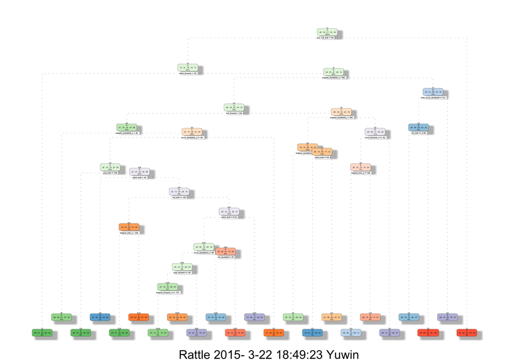

```r
fancyRpartPlot(modFitDT)
```

###Prediction Put the testing data which we did above into the model, and show the confusion matrix:

```r
predictionsDT <- predict(modFitDT, forTesting, type = "class")
confusionMatrix(predictionsDT, forTesting$classe)
```

```
## Confusion Matrix and Statistics
##
##           Reference
## Prediction    A    B    C    D    E
##          A 1998  358   40  157   88
##          B   45  844  108   42  109
##          C   42  140 1083  176  130
##          D   84  110   92  825   67
##          E   63   66   45   86 1048
##
## Overall Statistics
##
##                Accuracy : 0.739
##                  95% CI : (0.7291, 0.7487)
##     No Information Rate : 0.2845
##     P-Value [Acc > NIR] : < 2.2e-16
##
##                   Kappa : 0.6678
##  Mcnemar's Test P-Value : < 2.2e-16
##
## Statistics by Class:
##
##                      Class: A Class: B Class: C Class: D Class: E
## Sensitivity            0.8952   0.5560   0.7917   0.6415   0.7268
## Specificity            0.8855   0.9520   0.9247   0.9462   0.9594
## Pos Pred Value         0.7565   0.7352   0.6894   0.7003   0.8012
## Neg Pred Value         0.9550   0.8994   0.9546   0.9309   0.9397
## Prevalence             0.2845   0.1935   0.1744   0.1639   0.1838
## Detection Rate         0.2547   0.1076   0.1380   0.1051   0.1336
## Detection Prevalence   0.3366   0.1463   0.2002   0.1501   0.1667
## Balanced Accuracy      0.8903   0.7540   0.8582   0.7939   0.8431
```

## Machine Learning Algorithms: Random Forest

### Fitting Model

```r
modFitRF <- randomForest(classe ~. , data=forTraining)
```

### Prediction

Put the testing data which we did above into the model, and show the confusion matrix:

```r
predictionsRF <- predict(modFitRF, forTesting, type = "class")
confusionMatrix(predictionsRF, forTesting$classe)
```

```
## Confusion Matrix and Statistics
##
##           Reference
## Prediction    A    B    C    D    E
##          A 2232   14    0    0    0
##          B    0 1500   15    0    0
##          C    0    4 1353   11    1
##          D    0    0    0 1274    3
##          E    0    0    0    1 1438
##
## Overall Statistics
##
##                Accuracy : 0.9938
##                  95% CI : (0.9918, 0.9954)
##     No Information Rate : 0.2845
##     P-Value [Acc > NIR] : < 2.2e-16
##
##                   Kappa : 0.9921
##  Mcnemar's Test P-Value : NA
##
## Statistics by Class:
##
##                      Class: A Class: B Class: C Class: D Class: E
## Sensitivity            1.0000   0.9881   0.9890   0.9907   0.9972
## Specificity            0.9975   0.9976   0.9975   0.9995   0.9998
## Pos Pred Value         0.9938   0.9901   0.9883   0.9977   0.9993
## Neg Pred Value         1.0000   0.9972   0.9977   0.9982   0.9994
## Prevalence             0.2845   0.1935   0.1744   0.1639   0.1838
## Detection Rate         0.2845   0.1912   0.1724   0.1624   0.1833
## Detection Prevalence   0.2863   0.1931   0.1745   0.1628   0.1834
## Balanced Accuracy      0.9988   0.9929   0.9933   0.9951   0.9985
```

## Final Model

We can see that the Random Forest algorithm perform the better result.

```r
modFitRF
```

```
##
## Call:
##  randomForest(formula = classe ~ ., data = forTraining)
##                Type of random forest: classification
##                      Number of trees: 500
## No. of variables tried at each split: 7
##
##         OOB estimate of  error rate: 0.68%
## Confusion matrix:
##      A    B    C    D    E class.error
## A 3343    4    0    0    1 0.001493429
## B   15 2258    6    0    0 0.009214568
## C    0   14 2033    7    0 0.010223953
## D    0    0   23 1905    2 0.012953368
## E    0    0    2    6 2157 0.003695150
```

## Submit Anwser to the Assignment

```r
predictionsRF2 <- predict(modFitRF, testing, type = "class")
```

Function to generate files with predictions to submit for assignment

```r
pml_write_files = function(x){
  n = length(x)
  for(i in 1:n){
    filename = paste0("problem_id_",i,".txt")
    write.table(x[i],file=filename,quote=FALSE,row.names=FALSE,col.names=FALSE)
  }
}

pml_write_files(predictionsRF2)
```